# Activity Classifications using Practical Machine Learning

Bill Felix

July 25, 2015

# Executive Summary

The intent of this project is to predict the method in which exercises were performed for six participants performing barbell lifts. There are a total of five methods of performance; one correct method and four incorrect methods. Accelerometer data was collected from the belt, forearm, arm, and dumbbell during the lifts. The following is a data procedure to clean and explore the data, and then build a classification model using the Random Forest method to predict greater than 99% accuracy with less than 1% chance of Out of Sample Error. To view the resulting html file go here: http://rpubs.com/manlike_fox/95565

## Downloading and Importing Data

Locate the data files

```r
trainUrl <- "http://d396qusza40orc.cloudfront.net/predmachlearn/pml-training.csv"
testUrl <- "http://d396qusza40orc.cloudfront.net/predmachlearn/pml-testing.csv"
```

Background information on the data files: http://groupware.les.inf.puc-rio.br/har

```r
train <- read.csv(url(trainUrl), na.strings=c("NA","#DIV/0!",""))
test <- read.csv(url(testUrl), na.strings=c("NA",""))
```

Look at the dimensions of training data set

```
## [1] 19622   160
```

## Data Wrangling (variable selection)

Determine which variables should be kept for the model by removing columns that have missing values and removing columns that are factor variables such as `user_name`. Also, removing variables related to the timestamp of the observation.

```r
train <- train[,!sapply(train, function(x) any(is.na(x)))]
train <- train[,!sapply(train[,-60], function(x) any(is.factor(x)))]
train <- train[,-c(1:4)]

dim(train) ## look
```

```
## [1] 19622    53
```

Examining a common measurement captured by the four accelerometers to explore potential relationships. This example covers the `total_accel` feature. Grouping by the `classe` variable, a boxplot shows a few subtle differences.

```r
library(dplyr)
```

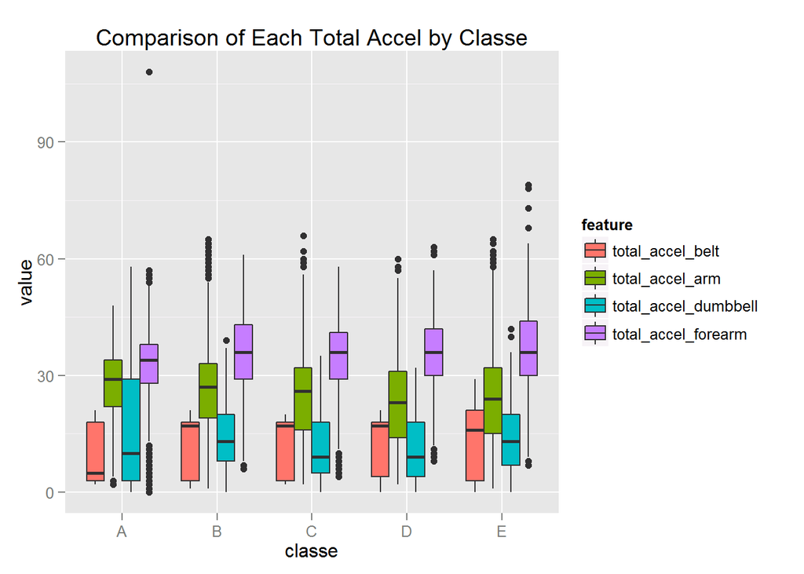

```r
library(tidyr)
library(ggplot2)

t_accel <- train %>% select(classe, starts_with("total")) %>%
    gather(feature, value, -classe)

qplot(x = classe, y = value
      , data = t_accel
      , geom = c("boxplot")
      , fill = feature
      , main = "Comparison of Each Total Accel by Classe")
```

# Building a Machine Learning Model

## Creating Training and Validation sets

To train our model we have created a partition using 70% of the training data. The remaining data will be used as validation and determining the Out of Sample error.

```r
library(caret)
library(AppliedPredictiveModeling)

set.seed(88)

## setup sets
ourTrain <- createDataPartition(y = train$classe , p = .70, list =F)
training <- train[ ourTrain,] ## create 1st partition
validating <- train[ -ourTrain,] ## create 2nd partition

dim(training) ## look
```

```
## [1] 13737    53
```

```r
dim(validating) ## look
```

```
## [1] 5885   53
```

## Fit the Model

Using the `caret` package is simple to experiment with different machine learning algorithms. The Random Forest method was chosen after researching algorithms specifically designed for classification. Random Forest uses a native bootstrap sampling method to migitigate potential overfitting for unseen data. Source: https://en.wikipedia.org/wiki/Random_forest

```r
library(dplyr)

data <- training[,1:52]
classe <- training$classe

fit <- train(x = data, y = classe
             , method = "rf")
print(fit$finalModel)
```

```
##
## Call:
##  randomForest(x = x, y = y, mtry = param$mtry)
##                Type of random forest: classification
##                      Number of trees: 500
## No. of variables tried at each split: 2
##
##         OOB estimate of  error rate: 0.7%
## Confusion matrix:
##      A    B    C    D    E  class.error
## A 3904    2    0    0    0 0.0005120328
## B   15 2635    8    0    0 0.0086531226
## C    0   21 2373    2    0 0.0095993322
## D    0    0   40 2211    1 0.0182060391
## E    0    0    1    6 2518 0.0027722772
```

Random Forest calculated the Out of Bag (OOB) rate above at 0.7%, which is below the original threshold set in the Executive Summary.

## Validation

The following procedure will look to uncover error rates for unforeseen data in the `validating` data set

```r
predicts <- predict(fit, validating[,1:52])
confusionMatrix(predicts, validating$classe)
```

```
## Confusion Matrix and Statistics
##
##           Reference
## Prediction    A    B    C    D    E
##          A 1674    7    0    0    0
##          B    0 1126   10    0    0
##          C    0    6 1016   17    0
##          D    0    0    0  944    2
##          E    0    0    0    3 1080
##
## Overall Statistics
##
##                Accuracy : 0.9924
##                  95% CI : (0.9898, 0.9944)
##     No Information Rate : 0.2845
##     P-Value [Acc > NIR] : < 2.2e-16
##
##                   Kappa : 0.9903
##  Mcnemar's Test P-Value : NA
##
## Statistics by Class:
##
##                      Class: A Class: B Class: C Class: D Class: E
## Sensitivity            1.0000   0.9886   0.9903   0.9793   0.9982
## Specificity            0.9983   0.9979   0.9953   0.9996   0.9994
## Pos Pred Value         0.9958   0.9912   0.9779   0.9979   0.9972
## Neg Pred Value         1.0000   0.9973   0.9979   0.9960   0.9996
## Prevalence             0.2845   0.1935   0.1743   0.1638   0.1839
## Detection Rate         0.2845   0.1913   0.1726   0.1604   0.1835
## Detection Prevalence   0.2856   0.1930   0.1766   0.1607   0.1840
## Balanced Accuracy      0.9992   0.9932   0.9928   0.9894   0.9988
```

## Results

The prediction shows 99.24% accuracy, which can be broken down by class and is shown visually below:

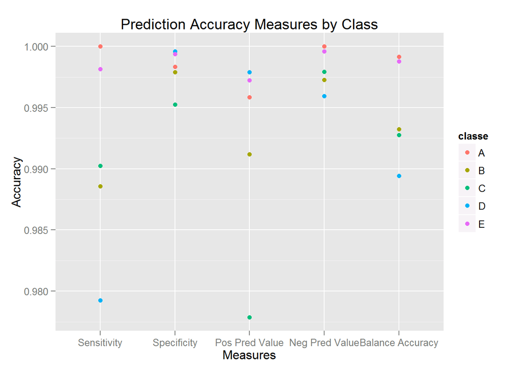

```r
looks <- confusionMatrix(predicts, validating$classe)[4]
viz <- as.data.frame(looks) %>% select(1:4, 8)%>% gather(var, value)
viz$classe <- rep(c("A","B","C","D","E"), 5)
levels(viz$var) <- c("Sensitivity", "Specificity", "Pos Pred Value", "Neg Pred Value", "Balance Accuracy")
qplot(x = var, y = value
      , data = viz
      , color = classe
      , main = "Prediction Accuracy Measures by Class"
      , ylab = "Accuracy"
      , xlab = "Measures")
```

## Conclusion

The Random Forest method proved to be a great method for this classification problem. The model does such a good job right out of the box that it was not necessary for further fine-tuning. There is room for performance fine-tuning using parallel resources; however, that was not in the scope of this project.

# Submissions

```r
test <- test[,!sapply(test, function(x) any(is.na(x)))]
test <- test[,!sapply(test[,-60], function(x) any(is.factor(x)))]
test <- test[,-c(1:4)]

dim(test)
```

#### Writing Out Submission Documents

```r
library(dplyr)

predictions <- predict(fit, newdata = test[,1:52])
print(predictions)
```

[output not shown]

```r
pml_write_files = function(x){
  n = length(x)
  for(i in 1:n){
    filename = paste0("./answers/problem_id_",i,".txt")
    write.table(x[i],file=filename,quote=FALSE,row.names=FALSE,col.names=FALSE)
  }
}

pml_write_files(predictions)
```